# Problem set 1

```r
knitr::opts_chunk$set(echo = TRUE, eval=TRUE)
```

```r
library(readxl)
library(ggplot2)
library(ggpubr)
library(data.table)
library(car)
data_path <- "../data_quizzes"
```

# Can I do simple regression?

1. source: https://datadryad.org/resource/doi:10.5061/dryad.6kp2n
2. file: Dryad file.xlsx
3. sheet: “Gradient decomp”

```r
folder <- "Data from Decay rates of leaf litters from arbuscular mycorrhizal trees are more sensitive to soil effects than litters from ectomycorrhizal trees"
filename <- "Dryad file.xlsx"
sheet_id <- "Gradient decomp"
file_path <- paste(data_path, folder, filename, sep="/")
litter <- data.table(read_excel(file_path, sheet=sheet_id))
setnames(litter, old=c("Litter type", "final k", "ave %ECM", "Inorganic N"), new=c("Litter_type", "final_k", "ECM", "Inorganic_N"))
```

1. The authors are intrested in litter decomposition rate (“final k”) as a function of the ectomycorrhizal fungi (“ave %ECM”) and how this differs in high quality litter (Maple) and low quality litter (Oak)
2. Plot this relationship separately for Maple and Oak. This can be in one plot or two different plots.

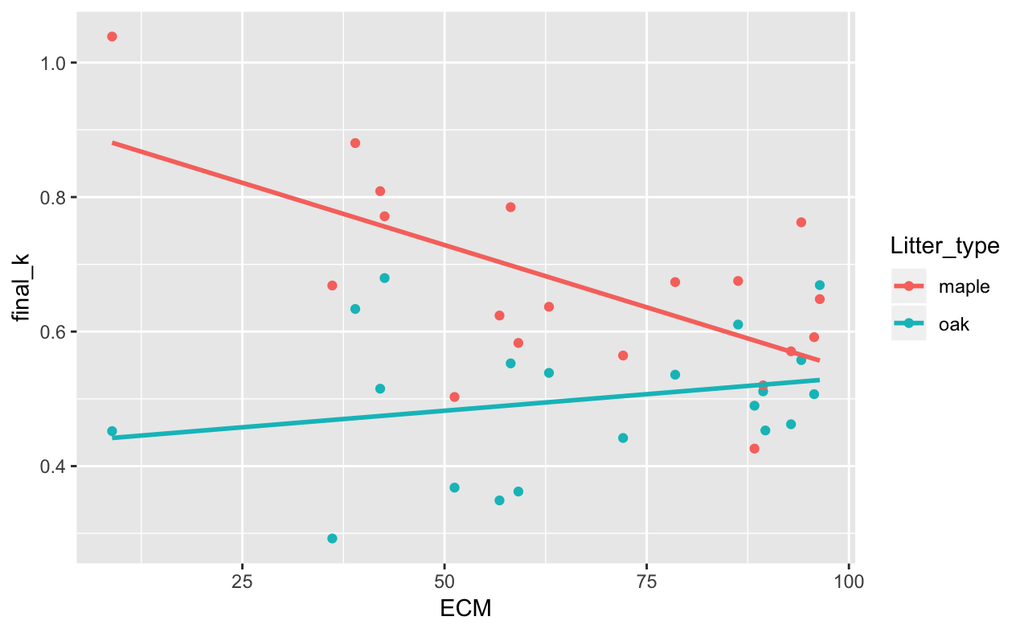

```r
qplot(x=ECM, y=final_k, data=litter, color=Litter_type) + geom_smooth(method="lm", se=FALSE)
```

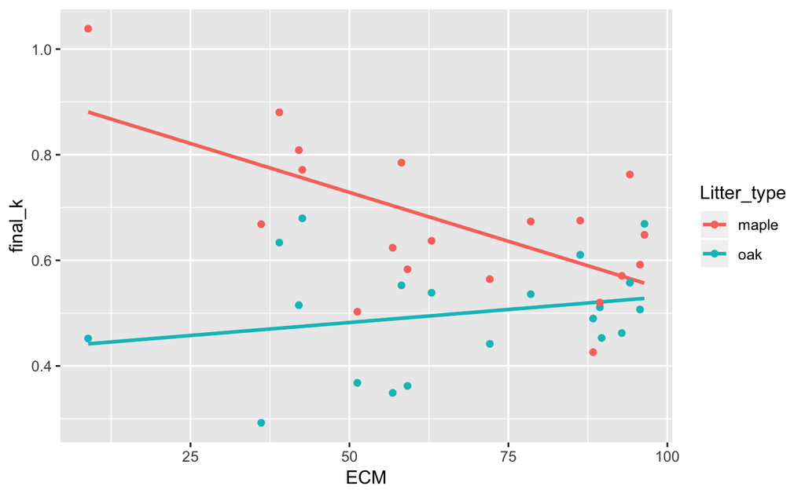

```r
# another way
gg <- ggplot(data=litter, aes(x=ECM, y=final_k, color=Litter_type)) +
  geom_smooth(method="lm", se=FALSE) +
  geom_point() +
  NULL
gg
```

3. Compute the effect of ECM on dcomposition rate in maple. Give the 95% confidence interval. Give the $R^2$ of the model.

```r
fit <- lm(final_k ~ ECM, data=litter[Litter_type=="maple"])
summary(fit)
```

```
Call:
lm(formula = final_k ~ ECM, data = litter[Litter_type == "maple"])

Residuals:
     Min       1Q   Median       3Q      Max
-0.22129 -0.08107  0.01528  0.08382  0.19716

Coefficients:
             Estimate Std. Error t value Pr(>|t|)
(Intercept)  0.913830   0.075453  12.111 8.74e-10 ***
ECM         -0.003703   0.001074  -3.447  0.00308 **
---
Signif. codes:  0 ‘***’ 0.001 ‘**’ 0.01 ‘*’ 0.05 ‘.’ 0.1 ‘ ’ 1

Residual standard error: 0.1147 on 17 degrees of freedom
Multiple R-squared:  0.4113,    Adjusted R-squared:  0.3767
F-statistic: 11.88 on 1 and 17 DF,  p-value: 0.003081
```

```r
coefficients(summary(fit))
```

```
                Estimate  Std. Error   t value     Pr(>|t|)
(Intercept)  0.913829848 0.075452633 12.111305 8.735740e-10
ECM         -0.003703022 0.001074422 -3.446527 3.081201e-03
```

```r
confint(fit)
```

```
                   2.5 %       97.5 %
(Intercept)  0.754638707  1.073020989
ECM         -0.005969854 -0.001436191
```

The $R^2$ is in the summary(fit) output.

# Can I do t-tests?

1. Use a classic (equal variance) t-test to test the hypothesis that litter decomposition rate is the same in oak and maple litter (ignore ECM and N). You can do this however you like.

specifying the two groups with a formula

```r
t.test(final_k~Litter_type, data=litter, var.equal=TRUE)
```

```
    Two Sample t-test

data:  final_k by Litter_type
t = 4.2218, df = 37, p-value = 0.000151
alternative hypothesis: true difference in means is not equal to 0
95 percent confidence interval:
 0.08895728 0.25314324
sample estimates:
mean in group maple   mean in group oak
          0.6701053           0.4990550
```

specifying the two groups by subsetting the data.table

```r
t.test(litter[Litter_type=="maple", final_k], litter[Litter_type=="oak", final_k], var.equal=TRUE)
```

[output not shown]

and of course the next question is also a t-test but using the linear model explicitly. Compare the t and p of the table in #2 below to the t.test output above

2. use a linear model to test the same hypothesis

```r
fit <- lm(final_k ~ Litter_type, data=litter)
coef(summary(fit))
```

```
                 Estimate Std. Error   t value     Pr(>|t|)
(Intercept)     0.6701053 0.02901403 23.095906 1.415192e-23
Litter_typeoak -0.1710503 0.04051589 -4.221807 1.509985e-04
```

# Can I estimate interaction effects?

sheet: “MC decomp”

The Stand column contains a variable that reflects if the stand is dominated by arbuscular mycorrhizae (AM) or ectomycorrhizae (ECM). This needs to be recoded to “AM” and “ECM”. I show how to do this below. The treatment column is fertilized (F) vs. unfertilized (UF)

1. Create a factor that is either AM or ECM – the two types of mycorhizae.

```r
sheet_id <- "MC decomp"
file_path <- paste(data_path, folder, filename, sep="/")
decomp <- data.table(read_excel(file_path, sheet=sheet_id))
```

```r
decomp[, Type:=ifelse(substr(decomp$Stand, 1, 2)=="AM", "AM", "ECM")]
# what is this doing? We are creating a new column "Type" and filling it with either "AM" if the first two letters of the entry in the column "Stand" is "AM" or filling it with "ECM" otherwise. The substr(x, start, end) function returns a substring of x starting from position start and ending end positions later. Play with it! It is just like Excel's MID function).
```

2. Fit a factorial linear model to estimate the interaction effect of (mycorrhizal) Type and (fertilization) Treatment as well as the effects of fertilization and ECM. Set AM/UF as the reference level.

```r
decomp[, Treatment:=factor(Treatment, c("UF", "F"))]
fit <- lm(k ~ Type*Treatment, data=decomp)
coef(summary(fit))
```

```
                      Estimate Std. Error    t value     Pr(>|t|)
(Intercept)         0.67786000 0.03793046 17.8711230 2.789710e-37
TypeECM            -0.12862667 0.05444847 -2.3623561 1.959803e-02
TreatmentF          0.03865714 0.05364178  0.7206537 4.723780e-01
TypeECM:TreatmentF -0.02410762 0.07643347 -0.3154066 7.529437e-01
```

# Can I do a type III factorial ANOVA?

Same as above, the additive and non-additive effects of Type and Treatment

```r
con3 <- list(Type=contr.sum, Treatment=contr.sum)
fit <- lm(k ~ Type*Treatment, data=decomp, contrasts=con3)
Anova(fit, type="3")
```

```
Anova Table (Type III tests)

Response: k
               Sum Sq  Df   F value    Pr(>F)
(Intercept)    54.190   1 1076.1622 < 2.2e-16 ***
Type            0.682   1   13.5507 0.0003355 ***
Treatment       0.024   1    0.4846 0.4875610
Type:Treatment  0.005   1    0.0995 0.7529437
Residuals       6.748 134
---
Signif. codes:  0 ‘***’ 0.001 ‘**’ 0.01 ‘*’ 0.05 ‘.’ 0.1 ‘ ’ 1
```

```r
# let's make this prettier
a_table <- Anova(fit, type="3")
knitr::kable(a_table[2:4,], digits=c(3,0,1,4))
```

|  | Sum Sq | Df | F value | Pr(>F) |
| --- | --- | --- | --- | --- |
| Type | 0.682 | 1 | 13.6 | 0.0003 |
| Treatment | 0.024 | 1 | 0.5 | 0.4876 |
| Type:Treatment | 0.005 | 1 | 0.1 | 0.7529 |